# Practical Machine Learning Course Project

Suman Adhikari

June 18, 2017

## Practical Machine Learning Course Project: Peer-graded Assignment

### Executive Summary:

Using devices such as Jawbone Up, Nike FuelBand, and Fitbit it is now possible to collect a large amount of data about personal activity relatively inexpensively. In this project, we are using datasets (Weight Lifting Exercise Dataset) obtained from [Human Activity Recognition](http://groupware.les.inf.puc-rio.br/har) using accelerometers on the belt, forearm, arm, and dumbell of 6 participants.

Participatns were asked to perform barbell lifts correctly and incorrectly in 5 different ways. The goal of our project is to predict the manner in which they did the exercise or to investigate “how (well)” an activity was performed by the wearer.

### Data

The data that have been used for this project was obtained from.

- [Training Data](https://d396qusza40orc.cloudfront.net/predmachlearn/pml-training.csv)
- [Test Data](https://d396qusza40orc.cloudfront.net/predmachlearn/pml-testing.csv)

### Processing and Cleaning Data

#### Load libraries

```r
# Load the required libraries
library(caret)
library(randomForest)
library(rpart)
library(rpart.plot)
library(corrplot)
```

#### Load the data

```r
# Load and Read the data
trainData<- read.csv("/R/workspace/data-machinelearn/pml-training.csv", sep=",", header=TRUE)
testData<- read.csv("/R/workspace/data-machinelearn/pml-testing.csv", sep=",", header=TRUE)
dim(trainData)
```

```
## [1] 19622   160
```

```r
dim(testData)
```

```
## [1]  20 160
```

The training data set contains 19622 observations and 160 variables, while the testing data set contains 20 observations and 160 variables. The “classe” variable in the training set is the outcome to predict.

#### Cleaning the data

Now in this step we will perform some operation to deal with missing values and roll out the variables which seems to meaningless to our analysis. The meaningless variables was first identified by analyzing trainData and removed, and identical removals was done on testData.

```r
# Rollout variables with nearly zero variance
nzvData <- nearZeroVar(trainData)
trainData <- trainData[, -nzvData]
testData <- testData[, -nzvData]

# Rollout variables that are almost always NA
mostlyNA <- sapply(trainData, function(x) mean(is.na(x))) > 0.95
trainData <- trainData[, mostlyNA==F]
testData <- testData[, mostlyNA==F]
```

Dealing with NA values, now we will exlcude variables which done contribute in our analysis.

```r
# Output is hidden
names(trainData)
```

```r
# Rollout variables which do not contribute on our analysis
trainData <- trainData[, -(1:5)]
testData <- testData[, -(1:5)]
dim(trainData)
```

```
## [1] 19622    54
```

```r
dim(testData)
```

```
## [1] 20 54
```

We observed that the cleaned training data set contains 19622 observations with 54 variables and testing data set contains 20 obeservations with 54 variables.

#### Slicing and Cross Validation

Now we will slice the cleaned data into actual traning data set comprising 70% of the of data and remaining comprising 30% of the data for validation. With successful slicing of the data we will use the validation data for cross validation.

```r
# Set the seed for reproducibililty
set.seed(22519)
inTrain <- createDataPartition(trainData$classe, p=0.70, list=F)
actTrainData <- trainData[inTrain, ]
actTestData <- trainData[-inTrain, ]
```

### Data Modelling

Now we will bulit model on basis of traning data set using Random Forest model with 3-fold cross validation

```r
# Train the model using 3-fold CV
fitControl <- trainControl(method="cv", number=3, verboseIter=F)

# fit model on actTrainData
fit <- train(classe ~ ., data=actTrainData, method="rf", trControl=fitControl)
fit$finalModel
```

```
##
## Call:
##  randomForest(x = x, y = y, mtry = param$mtry)
##                Type of random forest: classification
##                      Number of trees: 500
## No. of variables tried at each split: 27
##
##         OOB estimate of  error rate: 0.24%
## Confusion matrix:
##      A    B    C    D    E class.error
## A 3906    0    0    0    0 0.000000000
## B    6 2651    0    1    0 0.002633559
## C    0    7 2388    1    0 0.003338898
## D    0    0   10 2241    1 0.004884547
## E    0    1    0    6 2518 0.002772277
```

### Evaluation and Selection of Model

With building the model now, we will use the model to predict the label (classe) in actTestData and view the confusion matrix and make comparison wih actual labels.

```r
# Using model to predict classe in validation set i.e actTestData
predict <- predict(fit, newdata=actTestData)

confMat <- confusionMatrix(actTestData$classe, predict)
confMat
```

```
## Confusion Matrix and Statistics
##
##           Reference
## Prediction    A    B    C    D    E
##          A 1673    0    0    0    1
##          B    1 1136    2    0    0
##          C    0    0 1026    0    0
##          D    0    0    4  960    0
##          E    0    0    0    5 1077
##
## Overall Statistics
##
##                Accuracy : 0.9978
##                  95% CI : (0.9962, 0.9988)
##     No Information Rate : 0.2845
##     P-Value [Acc > NIR] : < 2.2e-16
##
##                   Kappa : 0.9972
##  Mcnemar's Test P-Value : NA
##
## Statistics by Class:
##
##                      Class: A Class: B Class: C Class: D Class: E
## Sensitivity            0.9994   1.0000   0.9942   0.9948   0.9991
## Specificity            0.9998   0.9994   1.0000   0.9992   0.9990
## Pos Pred Value         0.9994   0.9974   1.0000   0.9959   0.9954
## Neg Pred Value         0.9998   1.0000   0.9988   0.9990   0.9998
## Prevalence             0.2845   0.1930   0.1754   0.1640   0.1832
## Detection Rate         0.2843   0.1930   0.1743   0.1631   0.1830
## Detection Prevalence   0.2845   0.1935   0.1743   0.1638   0.1839
## Balanced Accuracy      0.9996   0.9997   0.9971   0.9970   0.9990
```

```r
# Show of out-of-sample error
oose <- 1 - as.numeric(confMat$overall[1])
oose
```

```
## [1] 0.002209006
```

So, the estimated accuracy of the model is 99.78% and the estimated out-of-sample error is 0.22%.

We can inefer that estimated accuracy of the model is 99.78% is an excellent resuolt, hence we stop trying additional algorithms and used Random Forests to predict test sets.

### Predicting for Test Data Set

Now, we apply the model to the original testing data set downloaded from the data source and write those predictions to individual files.

```r
predict <- predict(fit, newdata=testData)

# Show the predicted output
predict
```

```
##  [1] B A B A A E D B A A B C B A E E A B B B
## Levels: A B C D E
```

```r
# convert predictions to character vector
predict <- as.character(predict)

# create function to write predictions to files
pml_write_files <- function(x) {
    n <- length(x)
    for(i in 1:n) {
        filename <- paste0("problem_id_", i, ".txt")
        write.table(x[i], file=filename, quote=F, row.names=F, col.names=F)
    }
}

# create prediction files to submit
pml_write_files(predict)
```

### Appendix : Figures

1. Correlation Matrix Visualization

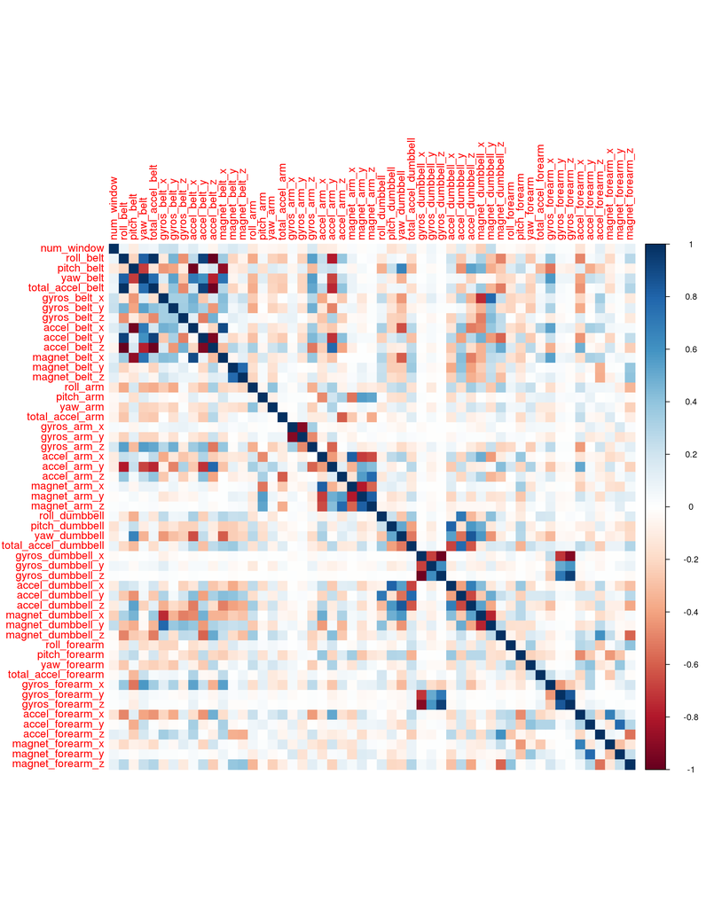

```r
corrPlot <- cor(trainData[, -length(names(trainData))])
corrplot(corrPlot, method="color")
```

2. Tree Visualization

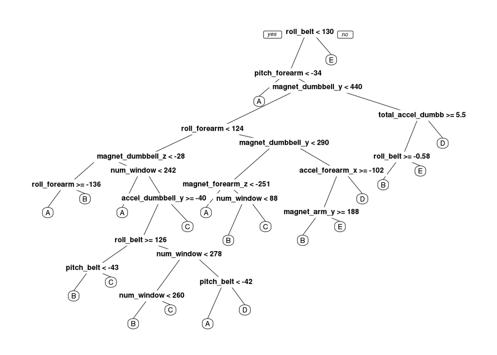

```r
treeModel <- rpart(classe ~ ., data=trainData, method="class")
prp(treeModel)
```